```python
import numpy as np
from scipy.io import wavfile
from scipy.fft import fft, fftfreq, rfft, rfftfreq
import matplotlib.pyplot as plt
#%matplotlib notebook
%matplotlib inline
import pyaudio
import wave
import sys
import math
from mpl_toolkits import mplot3d
```

# Load audio file

```python
def load_recording(fileName, start=None, end=None):
    if fileName[-4:] != ".wav": #Za enostavnejšo uporabniško izkušnjo končnico dodamo samodejno.
        fileName += ".wav"
    filePath = './posnetki/'
    Fv, data = wavfile.read(filePath + fileName) #Naložimo .wav datoteko
    posnetek = data.T[0] #Dobimo le prvi kanal.
    L = len(posnetek)
    T = round(L / Fv)
    if not start:
        start = 0
    if not end:
        end = T
    x = posnetek[round(start*Fv):round(end*Fv):1]
    params = {'L': L, 'T': T, 'Fv': Fv, 'start': start, 'end': end}
    return x, params
```

## Implementacija ST-DFT

```python
def framming(x, window_length=25, window_overlap = 0.5, Fv=16000):
    window_overlap = 1 - window_overlap
    if window_overlap == 0:
        window_overlap = 0.01
    frame_length = int(window_length/1000*Fv) #Dolžina okna v vzorcev
    frame_step = int(np.ceil(frame_length * window_overlap)) #Koliko vzorcev se prekriva
    frames_count = int(np.ceil(float(len(x) - frame_length) / frame_step)) #Končno število okvirjev

    padding_count = round(abs(len(x) - (frames_count * frame_step + frame_length))) #Padding za zadnji okvir
    padding = np.zeros(padding_count)
    x_padded = np.append(x, padding)

    indices1 = np.tile(np.arange(0, frame_length), (frames_count, 1))
    indices2 = np.tile(np.arange(0, frames_count*frame_step, frame_step), (frame_length, 1)).T
    indices = indices1 + indices2
    frames = x_padded[indices.astype(np.int32, copy=False)] #Signal razdelimo na okvirje
    return frames, indices

def STDFT(x, window_length=25, window_overlap=0.01, Fv=16000, NFFT=None, prints=True):
    frames, ind = framming(x, #Signal razdelimo na okvirje
                     window_length=window_length,
                     window_overlap=window_overlap,
                     Fv=Fv)
    if not NFFT:
        NFFT = frames.shape[1]

    if prints:
        print('Signal split into ' + str(frames.shape[0]) + ' frames of ' + str(frames.shape[1]) + ' samples.')
        if frames.shape[1] > NFFT:
            print('Frames (' + str(frames.shape[1]) + ') are longer than NFFT... May cause problems!')
            print('Try decreasing \'window_length (' +
                  str(window_length) + ')\' or increasing \'NFFT (' + str(NFFT) + ')\'')
    resX = rfft(frames, NFFT) #FFT nad vsakem okvirju
    resF = np.arange(0, NFFT//2 +1) #Frekvence
    #resF = np.arange(0, len(resX[0]))
    resT = ind[:, 0] #Časovni indeksi okvirjev
    return resX, resT, resF
```

# TESTNI PROBLEM

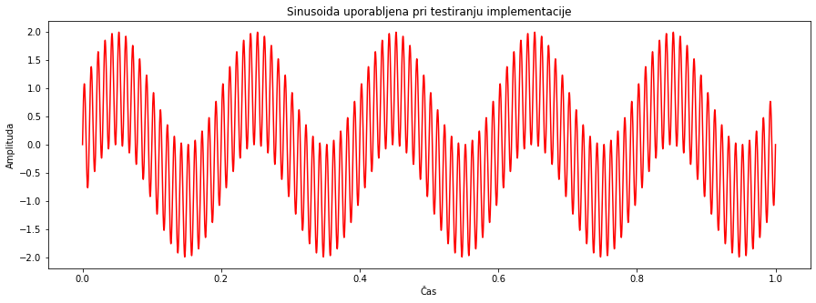

```python
Fv = 44100
T = 1
t = np.linspace(0, T, num=T*Fv)

#Parametri sinusoid
f1 = 5
faz1 = 0
A1 = 1
f2 = 100
faz2 = 0
A2 = 1

s1 = A1*np.sin(2*np.pi*f1*t + faz1)
s2 = A2*np.sin(2*np.pi*f2*t + faz2)
x = s1 + s2
#x = s1
plt.figure(figsize=(15, 5))
plt.title('Sinusoida uporabljena pri testiranju implementacije')
plt.xlabel('Čas')
plt.ylabel('Amplituda')
plt.plot(t, x, 'r')
```

```python
window_length = 100
window_overlap = 0.01
resX, resT, resF = STDFT(x,
                         window_length=window_length,
                         window_overlap=window_overlap,
                         Fv=Fv,
                         NFFT=Fv
                        )
```

```
Signal split into 10 frames of 4410 samples.
```

```python
print(resX.shape)
print(resT.shape)
print(resF.shape)
print(resT)
```

```
(10, 22051)
(10,)
(22051,)
[    0  4366  8732 13098 17464 21830 26196 30562 34928 39294]
```

```
(0.0, 512.0, 0.0, 150.0)
```

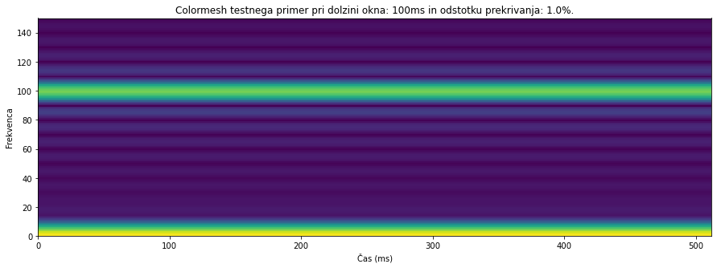

```python
plt.figure(figsize=(15, 5))
plt.pcolormesh(resT, resF, np.transpose(np.abs(resX)), shading='auto')
plt.title("Colormesh testnega primer pri dolzini okna: " + str(window_length)
          + "ms in odstotku prekrivanja: " + str(window_overlap*100) + "%.")
plt.ylabel("Frekvenca")
plt.xlabel("Čas (ms)")
plt.axis([0, 512, 0, 150]) #Uporabljeno za sliko sinusne funkcije pri žvižgu
```

## Primeri za vaje

```python
#recording = RECORD(CHUNK=1024, CHANNELS=2, RATE=Fv, DURATION=1)
recording = 'posnetki/eva_in_olu.wav'
Fv, data = wavfile.read(recording)
x = data.T[0]
T = round(len(x) / Fv)
t = np.linspace(0, T, num=T*(len(x)//T))
```

```python
window_length = 50
window_overlap = 0.5
resX, resT, resF = STDFT(x,
                         window_length = window_length,
                         window_overlap=window_overlap,
                         Fv=Fv,
                         NFFT=4112)
```

```
Signal split into 118 frames of 2205 samples.
```

```
(0.5, 3.0, 0.0, 200.0)
```

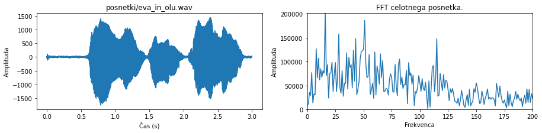

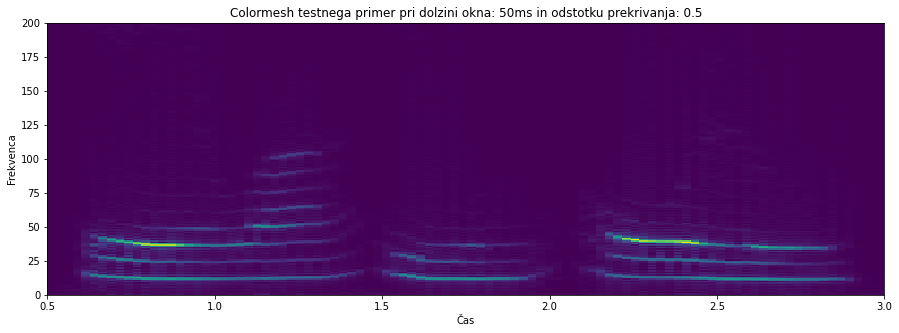

```python
fig, (ax1, ax2) = plt.subplots(1, 2, figsize=(15, 3))
t = np.linspace(0, 3, num=len(x))
ax1.plot(t, x)
ax1.set(xlabel='Čas (s)', ylabel='Amplituda')
ax1.set_title(recording)

X = rfft(x)
xf = np.arange(0, len(X))
ax2.plot(xf, np.abs(X))
ax2.set(xlabel='Frekvenca', ylabel='Amplituda')
ax2.set_title('FFT celotnega posnetka.')
plt.axis([0, 200, 0, max(np.abs(X[:200]))])

plt.figure(figsize=(15, 5))
osX = np.linspace(0, T, num=len(resT))
plt.pcolormesh(osX, resF, np.transpose(np.abs(resX)), shading='auto')
plt.title("Colormesh testnega primer pri dolzini okna: " + str(window_length)
          + "ms in odstotku prekrivanja: " + str(window_overlap))
plt.ylabel("Frekvenca")
plt.xlabel("Čas")
plt.axis([0.5, 3, 0, 200]) #Uporabljeno za sliko sinusne funkcije pri žvižgu"""
```

# Vprašanja iz vaj

### VPRAŠANJE 1

Kako je nestacionarnost signalov odvisna od hitrosti izgovorjave oz. ali se optimalna izbira dolžine intervalov za DFT in stopnje njihovega prekrivanja razlikuje od hitrosti izgovorjave?

**Odgovor:**  
Hitrejša kot je izgovorjava beseda bolj je signal nestacionaren oziroma pri počasnejši izgovorjavi imamo intervale posnetke, kjer je signal dokaj stacionaren (naprimer interval izgovorjave enega samoglasnika).  
Temu primerno moramo izbrati tudi dolžine intervalov za DFT:

- Počasnejša izgovorjave => daljši intervali
- Hitrejša izgovorjava => manjši intervali

**Testi:**  
Na posnetkih počasne in hitre besede utica 8 testov.  
Za velikosti okna (10, 25, 50, 100) in stopnje prekrivanja (0 in 50%)

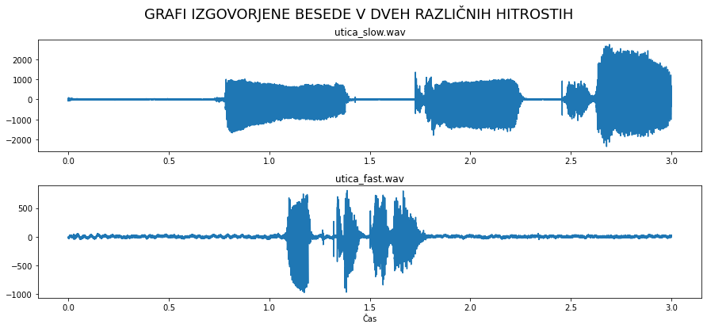

```python
#GRAFI IZGOVORJENE BESEDE V DVEH RAZLIČNIH HITROSTIH
posnetek1 = 'utica_slow.wav'
posnetek3 = 'utica_fast.wav'

fig, (ax1, ax2) = plt.subplots(2, 1, figsize=(15, 6))
fig.suptitle("GRAFI IZGOVORJENE BESEDE V DVEH RAZLIČNIH HITROSTIH", fontsize=18)
fig.subplots_adjust(hspace = 0.3)

#Počasna izgovorjava
x, params = load_recording(posnetek1)
t = np.linspace(params['start'], params['end'], num=len(x))
ax1.plot(t, x)
ax1.set_title(posnetek1)

#Hitra izgovorjava
x, params = load_recording(posnetek3)
t = np.linspace(params['start'], params['end'], num=len(x))
ax2.plot(t, x)
ax2.set(xlabel='Čas')
ax2.set_title(posnetek3)
```

#### TESTI NA POČASNEM POSNETKU

```
Signal split into 251 frames of 441 samples.
Signal split into 496 frames of 441 samples.
Signal split into 100 frames of 1102 samples.
Signal split into 198 frames of 1102 samples.
Signal split into 50 frames of 2205 samples.
Signal split into 98 frames of 2205 samples.
Signal split into 25 frames of 4410 samples.
Signal split into 48 frames of 4410 samples.
```

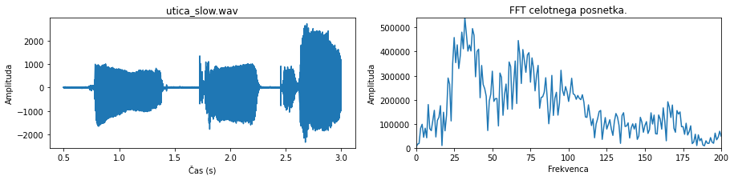

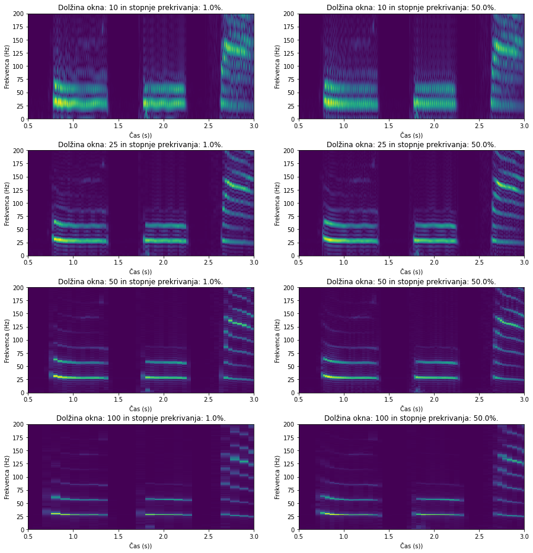

```python
x, params = load_recording(posnetek1, start=0.5, end=3) #Hitra izgovorjava
NFFT = 8224 #4112, 8224

fig, (ax1, ax2) = plt.subplots(1, 2, figsize=(15, 3))

t = np.linspace(params['start'], params['end'], num=len(x))
ax1.plot(t, x)
ax1.set(xlabel='Čas (s)', ylabel='Amplituda')
ax1.set_title(posnetek1)

X = rfft(x)
xf = np.arange(0, len(X))
ax2.plot(xf, np.abs(X))
ax2.set(xlabel='Frekvenca', ylabel='Amplituda')
ax2.set_title('FFT celotnega posnetka.')
plt.axis([0, 200, 0, max(np.abs(X[:200]))])

fig, ((ax1, ax2), (ax3, ax4), (ax5, ax6), (ax7, ax8)) = plt.subplots(4, 2, figsize=(15, 16))
fig.subplots_adjust(hspace = 0.3)
axes = [ax1, ax2, ax3, ax4, ax5, ax6, ax7, ax8]
window_lengths = [10, 25, 50, 100] #V ms
window_overlaps = [0.01, 0.5]
index = 0
for i, win_len in enumerate(window_lengths):
    for j, win_over in enumerate(window_overlaps):
        resX, resT, resF = STDFT(x,
                             window_length=win_len,
                             window_overlap=win_over,
                             Fv=params['Fv'],
                             NFFT=NFFT)
        osX = np.linspace(params['start'], params['end'], num=len(resT))
        axes[index].set_title('Dolžina okna: ' + str(win_len) + ' in stopnje prekrivanja: ' + str(win_over*100) + '%.')
        axes[index].set(xlabel='Čas (s))', ylabel='Frekvenca (Hz)')
        axes[index].pcolormesh(osX, resF, np.transpose(np.abs(resX)), shading='auto')
        axes[index].axis([params['start'], params['end'], 0, 200])
        index += 1
```

#### TESTI NA HITREM POSNETKU

```
Signal split into 100 frames of 441 samples.
Signal split into 198 frames of 441 samples.
Signal split into 40 frames of 1102 samples.
Signal split into 79 frames of 1102 samples.
Signal split into 20 frames of 2205 samples.
Signal split into 38 frames of 2205 samples.
Signal split into 10 frames of 4410 samples.
Signal split into 18 frames of 4410 samples.
```

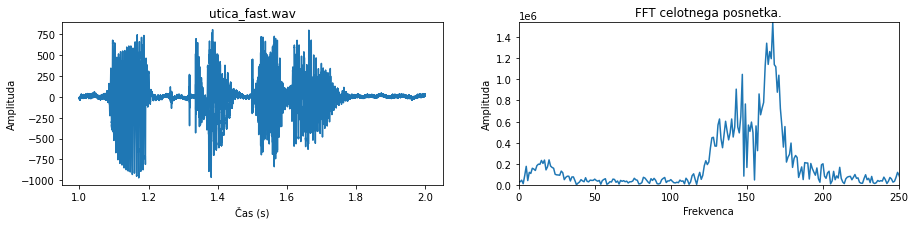

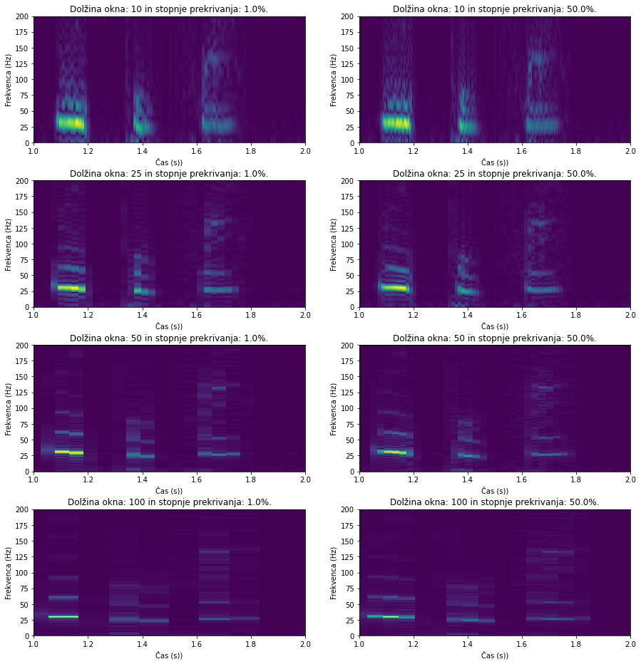

```python
x, params = load_recording(posnetek3, start=1, end=2) #Hitra izgovorjava
NFFT = 8224 #4112, 8224

fig, (ax1, ax2) = plt.subplots(1, 2, figsize=(15, 3))

t = np.linspace(params['start'], params['end'], num=len(x))
ax1.plot(t, x)
ax1.set(xlabel='Čas (s)', ylabel='Amplituda')
ax1.set_title(posnetek3)

X = rfft(x)
xf = np.arange(0, len(X))
ax2.plot(xf, np.abs(X))
ax2.set(xlabel='Frekvenca', ylabel='Amplituda')
ax2.set_title('FFT celotnega posnetka.')
plt.axis([0, 250, 0, max(np.abs(X[:250]))])

fig, ((ax1, ax2), (ax3, ax4), (ax5, ax6), (ax7, ax8)) = plt.subplots(4, 2, figsize=(15, 16))
fig.subplots_adjust(hspace = 0.3)
axes = [ax1, ax2, ax3, ax4, ax5, ax6, ax7, ax8]
window_lengths = [10, 25, 50, 100] #V ms
window_overlaps = [0.01, 0.5]
index = 0
for i, win_len in enumerate(window_lengths):
    for j, win_over in enumerate(window_overlaps):
        resX, resT, resF = STDFT(x,
                             window_length=win_len,
                             window_overlap=win_over,
                             Fv=params['Fv'],
                             NFFT=NFFT)
        osX = np.linspace(params['start'], params['end'], num=len(resT))
        axes[index].set_title('Dolžina okna: ' + str(win_len) + ' in stopnje prekrivanja: ' + str(win_over*100) + '%.')
        axes[index].set(xlabel='Čas (s))', ylabel='Frekvenca (Hz)')
        axes[index].pcolormesh(osX, resF, np.transpose(np.abs(resX)), shading='auto')
        axes[index].axis([params['start'], params['end'], 0, 200])
        index += 1
```

### VPRAŠANJE 2

Kako se z izbiro dolžine intervalov spreminja zaznava višjih harmonikov v frekvenčni sliki posameznih intervalov?

**Odgovor:**  
Pri daljši izbiri okna lažje enolično določimo višje harmonike v frekvenčni sliki. Pri manjših oknih so meje prehodov manj vidne (posebej pri prikazu s spektogramo.

(Glej spodnji sliki prikaza višjih harmonikov)

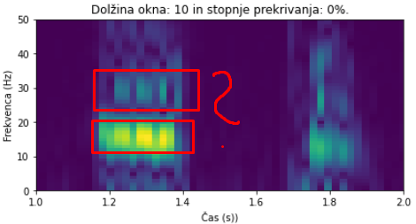

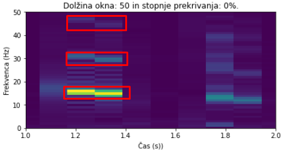

### VPRAŠANJE 3

Kako izbira dolžine intervalov spreminja razlikovanje med samoglasniki slovenske abecede?

**Odgovor:**  
Zelo majhna okna (10ms) utežijo razlikovanje med samoglasniki. Večja okna (25, 50 in 100ms) omogočijo boljše razlikovanje in sicer, večje kot je okno lažje se prepoznajo različni samoglasniki.

#### STDFT za eno sekundni posnetek vsakega samoglasnika

```
Signal split into 38 frames of 2205 samples.
Signal split into 38 frames of 2205 samples.
Signal split into 38 frames of 2205 samples.
Signal split into 38 frames of 2205 samples.
Signal split into 38 frames of 2205 samples.
```

```
(0.0, 1.0, 0.0, 1.0)
```

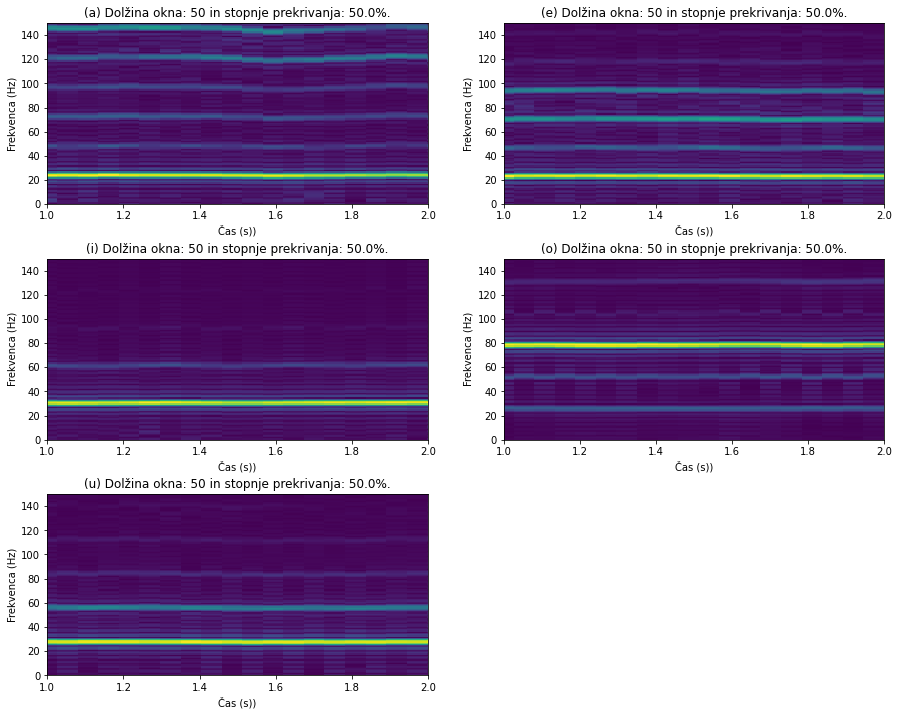

```python
samoglasniki = ['a', 'e', 'i', 'o', 'u']
window_length=50
window_overlap=0.5
fig, ((ax1, ax2), (ax3, ax4), (ax5, ax6)) = plt.subplots(3, 2, figsize=(15, 12))
fig.subplots_adjust(hspace = 0.3)
axes = [ax1, ax2, ax3, ax4, ax5]
for i, samoglasnik in enumerate(samoglasniki):
    x, params = load_recording(samoglasnik, start=1, end=2)
    resX, resT, resF = STDFT(x,
                             window_length=window_length,
                             window_overlap=window_overlap,
                             Fv=params['Fv'],
                             NFFT=NFFT)
    osX = np.linspace(params['start'], params['T'], num=len(resT))
    axes[i].set_title('(' + samoglasnik + ') Dolžina okna: ' + str(window_length) + ' in stopnje prekrivanja: ' + str(window_overlap*100) + '%.')
    axes[i].set(xlabel='Čas (s))', ylabel='Frekvenca (Hz)')
    axes[i].pcolormesh(osX, resF, np.transpose(np.abs(resX)), shading='auto')
    axes[i].axis([params['start'], params['end'], 0, 150])
ax6.axis('off')
```

#### 3s posnetek, ki je sestavljen iz 0.6s posnetka vsakega samoglasnika

```
Signal split into 302 frames of 441 samples.
Signal split into 597 frames of 441 samples.
Signal split into 121 frames of 1102 samples.
Signal split into 239 frames of 1102 samples.
Signal split into 60 frames of 2205 samples.
Signal split into 118 frames of 2205 samples.
Signal split into 30 frames of 4410 samples.
Signal split into 58 frames of 4410 samples.
```

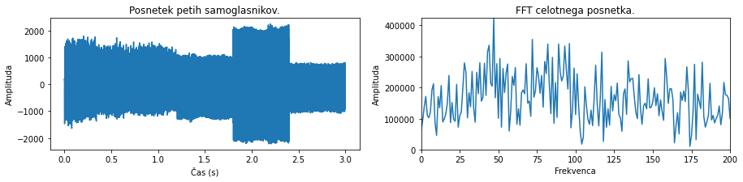

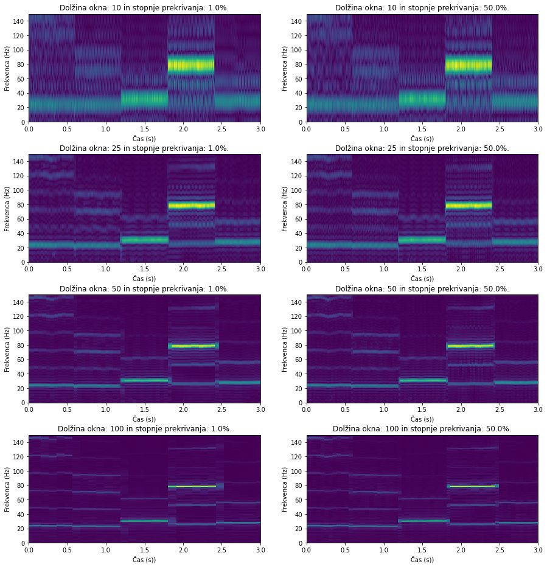

```python
samoglasniki = ['a', 'e', 'i', 'o', 'u']
Fv = 44100
x = np.zeros(3*Fv)
for i, samoglasnik in enumerate(samoglasniki):
    _x, params = load_recording(samoglasnik, start=1, end=1.6)
    x[i*len(_x):(i+1)*len(_x)] = _x

fig, (ax1, ax2) = plt.subplots(1, 2, figsize=(15, 3))
t = np.linspace(0, 3, num=len(x))
ax1.plot(t, x)
ax1.set(xlabel='Čas (s)', ylabel='Amplituda')
ax1.set_title('Posnetek petih samoglasnikov.')

X = rfft(x)
xf = np.arange(0, len(X))
ax2.plot(xf, np.abs(X))
ax2.set(xlabel='Frekvenca', ylabel='Amplituda')
ax2.set_title('FFT celotnega posnetka.')
plt.axis([0, 200, 0, max(np.abs(X[:200]))])

fig, ((ax1, ax2), (ax3, ax4), (ax5, ax6), (ax7, ax8)) = plt.subplots(4, 2, figsize=(15, 16))
fig.subplots_adjust(hspace = 0.3)
axes = [ax1, ax2, ax3, ax4, ax5, ax6, ax7, ax8]
window_lengths = [10, 25, 50, 100] #V ms
window_overlaps = [0.01, 0.5]
index = 0
for i, win_len in enumerate(window_lengths):
    for j, win_over in enumerate(window_overlaps):
        resX, resT, resF = STDFT(x,
                             window_length=win_len,
                             window_overlap=win_over,
                             Fv=params['Fv'],
                             NFFT=NFFT)
        osX = np.linspace(0, 3, num=len(resT))
        axes[index].set_title('Dolžina okna: ' + str(win_len) + ' in stopnje prekrivanja: ' + str(win_over*100) + '%.')
        axes[index].set(xlabel='Čas (s))', ylabel='Frekvenca (Hz)')
        axes[index].pcolormesh(osX, resF, np.transpose(np.abs(resX)), shading='auto')
        axes[index].axis([0, 3, 0, 150])
        index += 1
```

### VPRAŠANJE 4

Kako izbira dolžine intervalov spreminja razlikovanje med soglasnikoma "r" in "š"?

```
Signal split into 60 frames of 2205 samples.
Signal split into 60 frames of 2205 samples.
```

```
(0.0, 3.0, 0.0, 100.0)
```

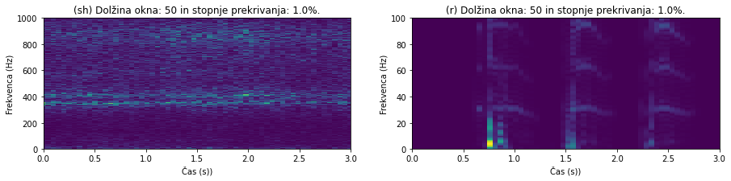

```python
soglasnika = ['sh', 'r']
window_length=50
window_overlap=0.01
fig, ((ax1, ax2)) = plt.subplots(1, 2, figsize=(15, 3))
fig.subplots_adjust(hspace = 0.3)
axes = [ax1, ax2, ax3, ax4, ax5]
for i, soglasnik in enumerate(soglasnika):
    x, params = load_recording(soglasnik, start=0, end=3)
    resX, resT, resF = STDFT(x,
                             window_length=window_length,
                             window_overlap=window_overlap,
                             Fv=params['Fv'],
                             NFFT=NFFT)
    osX = np.linspace(params['start'], params['T'], num=len(resT))
    axes[i].set_title('(' + soglasnik + ') Dolžina okna: '
                      + str(window_length) + ' in stopnje prekrivanja: ' + str(window_overlap*100) + '%.')
    axes[i].set(xlabel='Čas (s))', ylabel='Frekvenca (Hz)')
    axes[i].pcolormesh(osX, resF, np.transpose(np.abs(resX)), shading='auto')
ax1.axis([params['start'], params['end'], 0, 1000])
ax2.axis([params['start'], params['end'], 0, 100])
```